# 📊**Projet Data Science : Analyse des ventes e-commerce avec Python et Power BI**

Ce projet a pour objectif d'explorer et visualiser un jeu de données de ventes e-commerce, en utilisant Python pour l'analyse et Power BI pour les visualisations interactives.

## 📥 **Étape 1 : Chargement des données**

Nous utilisons la bibliothèque `pandas` pour charger le fichier CSV contenant les transactions de vente. Nous affichons également les premières lignes pour comprendre la structure du jeu de données.

### Importation des packages utiles

```python
import pandas as pd

import matplotlib.pyplot as plt

import seaborn as sns

import numpy as np
```

```python
#Définition du thème général
sns.set_theme(
    style="whitegrid",
    context="notebook",
    font_scale=1.2
)

plt.rcParams.update({
    'axes.titlesize':16,
    'axes.titleweight':'bold',
    'axes.labelsize':14,
    'axes.labelweight':'bold',
    'xtick.labelsize':12,
    'ytick.labelsize':12,
    'figure.titlesize':18
})
```

```python
###Chargement du fichier CSV
df = pd.read_csv("F:/python/datascience-env/ecommerce_data_fichier_dates_uniformes.csv")

###Affichage des premières lignes
df.head(10)

###Dimensions du dataset, type de données et résumé statistiques des colonnes numériques
#print(f"Nombre de lignes et colonnes : {df.shape}")
#print(f"\nTypes de colonnes: \n{df.dtypes}")
#print(f"\nStatistiques: \n{df.describe()}")
```

|  | InvoiceNo | Date | CustomerID | Country | Product | Quantity | UnitPrice |
| --- | --- | --- | --- | --- | --- | --- | --- |
| 0 | INV10000 | 18-02-2025 | 1086 | United Kingdom | Mouse | 1 | 377.62 |
| 1 | INV10001 | 12-05-2025 | 1099 | France | Webcam | 8 | 757.27 |
| 2 | INV10002 | 16-02-2025 | 1045 | United Kingdom | USB Cable | 10 | 117.89 |
| 3 | INV10003 | 08-05-2025 | 1017 | Italy | Webcam | 1 | 708.41 |
| 4 | INV10004 | 22-12-2024 | 1047 | France | USB Cable | 10 | 939.86 |
| 5 | INV10005 | 21-12-2024 | 1001 | Germany | Webcam | 1 | 696.83 |
| 6 | INV10006 | 21-02-2025 | 1096 | Italy | Laptop | 10 | 968.29 |
| 7 | INV10007 | 17-01-2025 | 1060 | United Kingdom | Keyboard | 5 | 950.30 |
| 8 | INV10008 | 17-01-2025 | 1070 | France | USB Cable | 7 | 395.32 |
| 9 | INV10009 | 05-04-2025 | 1007 | United Kingdom | Keyboard | 1 | 521.38 |

## 🧼 **Étape 2 : Nettoyage des données**

Les opérations de nettoyage comprennent :

- Suppression des lignes avec des valeurs manquantes dans les colonnes clés (`CustomerID`, `Product`, `Country`)
- Conversion de la colonne `Date` au format datetime
- Ajout d'une colonne `TotalPrice = Quantity * UnitPrice`

```python
#Vérifier valeurs manquantes:montre combien de valeurs manquantes il y a par colonne
df.isnull().sum()
```

```
InvoiceNo     0
Date          0
CustomerID    0
Country       0
Product       0
Quantity      0
UnitPrice     0
dtype: int64
```

```python
#Supprime les lignes avec des valeurs critiques manquantes
df_cleaned = df.dropna(subset=["CustomerID" , "Product" , "Country"])

#Vérifier les types de données(surtout la date qui doit être en datetime64)
df_cleaned.dtypes

#Conversion de la colonne Date
df_cleaned["Date"] = pd.to_datetime(df_cleaned["Date"])
```

```
C:\Users\User HP\AppData\Local\Temp\ipykernel_4332\2713636950.py:8: UserWarning: Parsing dates in %d-%m-%Y format when dayfirst=False (the default) was specified. Pass `dayfirst=True` or specify a format to silence this warning.
  df_cleaned["Date"] = pd.to_datetime(df_cleaned["Date"])
```

```python
#Ajout d'une colonne TotalPrice
df_cleaned["TotalPrice"] = df_cleaned["Quantity"] * df_cleaned["UnitPrice"]

df_cleaned.head(5)
```

|  | InvoiceNo | Date | CustomerID | Country | Product | Quantity | UnitPrice | TotalPrice |
| --- | --- | --- | --- | --- | --- | --- | --- | --- |
| 0 | INV10000 | 2025-02-18 | 1086 | United Kingdom | Mouse | 1 | 377.62 | 377.62 |
| 1 | INV10001 | 2025-05-12 | 1099 | France | Webcam | 8 | 757.27 | 6058.16 |
| 2 | INV10002 | 2025-02-16 | 1045 | United Kingdom | USB Cable | 10 | 117.89 | 1178.90 |
| 3 | INV10003 | 2025-05-08 | 1017 | Italy | Webcam | 1 | 708.41 | 708.41 |
| 4 | INV10004 | 2024-12-22 | 1047 | France | USB Cable | 10 | 939.86 | 9398.60 |

## 🔍 **Étape 3 : Analyse exploratoire des données (EDA)**

Nous analysons le comportement des ventes via :

- Le chiffre d'affaires total
- Les ventes par pays
- Les produits les plus vendus
- Les tendances de ventes dans le temps

```python
#Chiffre d'affaire
ca_total = df_cleaned["TotalPrice"].sum()

print(f"Chiffre d'affaires total: {ca_total:.2f}€")
```

```
Chiffre d'affaires total: 529695.42€
```

### 🌍Top 10 CA par Pays

[output not shown]

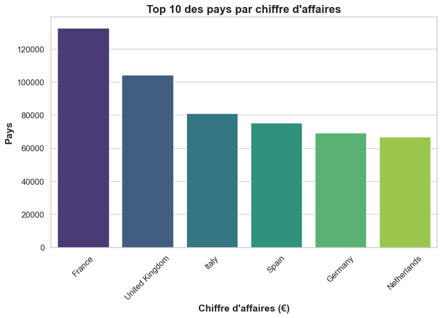

```python
#Vente par pays
top_10_countries = df_cleaned.groupby("Country")["TotalPrice"].sum().sort_values(ascending=False).head(10)
top_10_countries_df = top_10_countries.reset_index()
top_10_countries_df.columns = ["Country" , "TotalPrice"]

plt.figure(figsize=(10 , 6))
sns.barplot(data= top_10_countries_df , x = "Country" , y = "TotalPrice" , hue="Country" , palette = "viridis" , legend = False)
plt.title("Top 10 des pays par chiffre d'affaires")
plt.xlabel("Chiffre d'affaires (€)")
plt.ylabel("Pays")
plt.xticks(rotation = 45)
```

### 📈Top '10' des produits les plus vendus

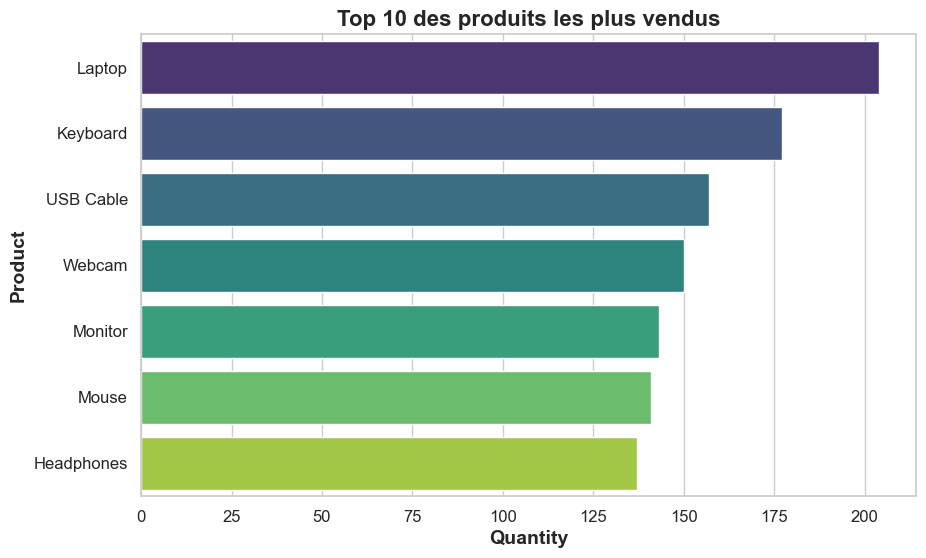

```python
# Top 10 des produits les plus vendus (par produits et quantité)
ventes_par_quantite = df_cleaned.groupby("Product")["Quantity"].sum().sort_values(ascending=False)

#Convertion de la Serie en DataFrame
ventes_par_quantite_df = ventes_par_quantite.reset_index()
ventes_par_quantite_df.columns = ["Product" , "Quantity"]

#Affichage via seaborn
plt.figure(figsize= (10 , 6))
sns.barplot(data= ventes_par_quantite_df , x = "Quantity" , y = "Product" , hue= "Product" , palette = "viridis" , legend= False )
plt.title("Top 10 des produits les plus vendus")
```

### ⏳Evolution dans le temps du CA

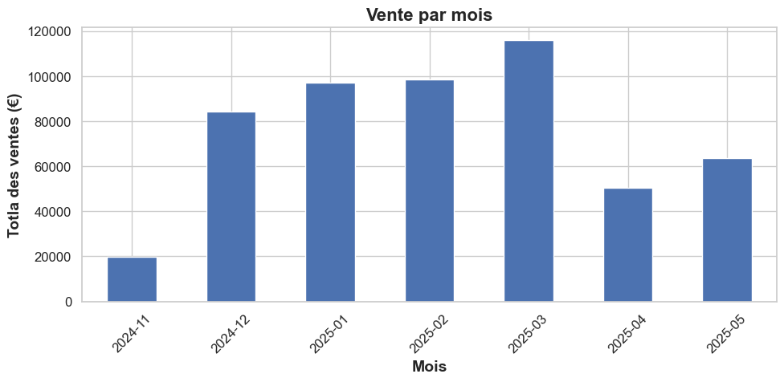

```python
#Evolution des ventes dans le temps (par mois)
df_cleaned["Month"] = df_cleaned["Date"].dt.to_period("M")

ventes_par_mois = df_cleaned.groupby("Month")["TotalPrice"].sum()

#Affichage graphique
ventes_par_mois.plot(kind = "bar" , figsize = (10 , 5) , title = "Vente par mois")

plt.ylabel("Totla des ventes (€)")
plt.xlabel("Mois")
plt.xticks(rotation = 45)
plt.tight_layout()
plt.show()
```

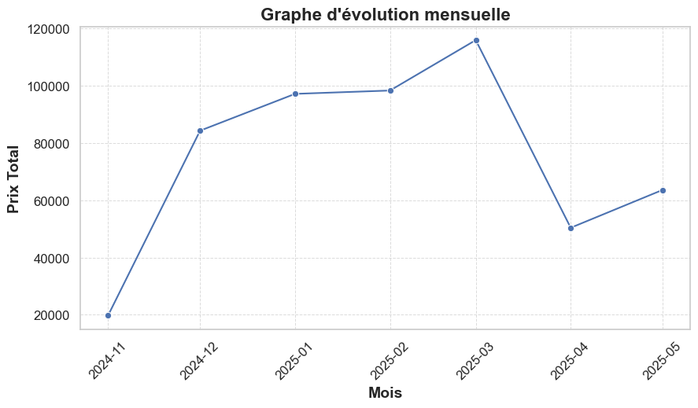

```python
ventes_par_mois_df = ventes_par_mois.reset_index()
ventes_par_mois_df["Month"] = ventes_par_mois_df["Month"].dt.to_timestamp()

plt.figure(figsize= (10, 5))
sns.lineplot(
    data = ventes_par_mois_df,
    x = "Month",
    y= "TotalPrice",
    marker= 'o',
    dashes=False,
    legend=False
)
sns.set_style("whitegrid")
plt.title("Graphe d'évolution mensuelle" , fontweight="bold", fontsize=16)
plt.xlabel("Mois", fontsize = 14, fontweight= "bold")
plt.ylabel("Prix Total", fontsize = 14, fontweight= "bold")
plt.xticks(rotation=45)
plt.tick_params(axis='x', which='major', length=6, width=1.5)
plt.tick_params(axis='y', which='major', length=6, width=1.5)
plt.grid(True, linestyle='--', linewidth=0.7, alpha=0.7)
plt.rcParams["font.family"] = "Calibri"
```

### Répartition des montants par pays

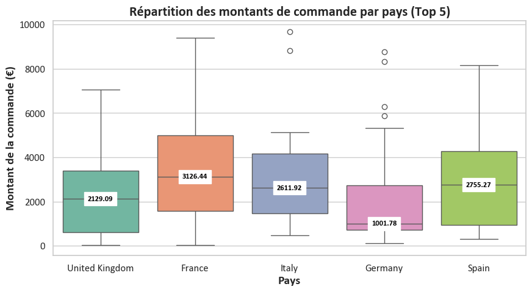

```python
top_5_countries = top_10_countries_df["Country"].head(5).tolist()
top_5_countries_df = df_cleaned[df_cleaned["Country"].isin(top_5_countries)]

plt.figure(figsize= (10, 5))
ax = sns.boxplot(data = top_5_countries_df , x= "Country" , y= "TotalPrice" , hue= "Country" , palette= "Set2" , legend=False)
plt.title("Répartition des montants de commande par pays (Top 5)" , fontweight="bold", fontsize=16)
plt.xlabel("Pays", fontweight="bold", fontsize=14)
plt.ylabel("Montant de la commande (€)", fontweight="bold", fontsize=14)

# Récupérer les groupes (ordre des pays affichés sur l'axe x)
groupe = ax.get_xticklabels()
countries = [label.get_text() for label in groupe]

# Pour chaque boîte, calculer la médiane et annoter au bon endroit
for i, country in enumerate(countries):
    data = top_5_countries_df.loc[top_5_countries_df["Country"] == country, "TotalPrice"].dropna()
    mediane = np.median(data)
    # Les positions x sont 0, 1, 2, ...
    plt.text(i, mediane, f'{mediane:.2f}',
             ha='center', va= 'center',
             fontsize=9, fontweight='bold', color='black',
             backgroundcolor='white')
```

## ⚖️ Analyse **RFM**

RFM signifie :

- `Recency` (Récence) : Quand le client a-t-il acheté pour la dernière fois ?
- `Frequency` (Fréquence) : Combien de fois le client a-t-il acheté ?
- `Monetary` (Montant) : Quel est le montant total dépensé par le client ?

Le but de cette analyse est de segmenter les clients en fonction de leur comportement d’achat, par exemple :

- Clients fidèles et rentables
- Clients qui n’achètent plus (à relancer)
- Nouveaux clients prometteurs
- Clients occasionnels, etc.

Cela permet d’adapter la stratégie marketing (offres ciblées, fidélisation, etc.).

1. Calcul de **R, F, M**

```python
# Date de référence (souvent le lendemain de la dernière date)
date_ref = df_cleaned['Date'].max() + pd.Timedelta(days=1)

rfm = df_cleaned.groupby("CustomerID").agg({
    'Date': lambda x: (date_ref - x.max()).days,    # Récence en jours
    'InvoiceNo':'nunique',                          # Fréquence
    'TotalPrice': 'sum'                             # Montant
})
#Renommage
rfm.columns = ["Recency" , "Frequency" , "Monetary"]
rfm.head(5)
```

| CustomerID | Recency | Frequency | Monetary |
| --- | --- | --- | --- |
| 1000 | 129 | 1 | 590.60 |
| 1001 | 61 | 3 | 4631.97 |
| 1002 | 19 | 5 | 12829.84 |
| 1003 | 173 | 1 | 2257.08 |
| 1004 | 7 | 2 | 3970.35 |

2. **Scoring**: création des scores (en 5 classes par quartiles)

```python
rfm['R_Score'] = pd.qcut(rfm['Recency'], 5, labels=range(5, 0, -1))
rfm['F_Score'] = pd.qcut(rfm['Frequency'].rank(method='first'), 5, labels=range(1,  6))
rfm['M_Score'] = pd.qcut(rfm['Monetary'].rank(method='first'), 5, labels=range(1, 6))

rfm.head(5)
```

| CustomerID | Recency | Frequency | Monetary | R_Score | F_Score | M_Score |
| --- | --- | --- | --- | --- | --- | --- |
| 1000 | 129 | 1 | 590.60 | 1 | 1 | 1 |
| 1001 | 61 | 3 | 4631.97 | 3 | 4 | 3 |
| 1002 | 19 | 5 | 12829.84 | 4 | 5 | 5 |
| 1003 | 173 | 1 | 2257.08 | 1 | 1 | 2 |
| 1004 | 7 | 2 | 3970.35 | 5 | 2 | 3 |

3. Combiner en code **RFM**

```python
rfm['RFM_Score'] = rfm['R_Score'].astype(str) + rfm['F_Score'].astype(str) + rfm['M_Score'].astype(str)

rfm.head(5)
```

| CustomerID | Recency | Frequency | Monetary | R_Score | F_Score | M_Score | RFM_Score |
| --- | --- | --- | --- | --- | --- | --- | --- |
| 1000 | 129 | 1 | 590.60 | 1 | 1 | 1 | 111 |
| 1001 | 61 | 3 | 4631.97 | 3 | 4 | 3 | 343 |
| 1002 | 19 | 5 | 12829.84 | 4 | 5 | 5 | 455 |
| 1003 | 173 | 1 | 2257.08 | 1 | 1 | 2 | 112 |
| 1004 | 7 | 2 | 3970.35 | 5 | 2 | 3 | 523 |

4. Profil client: création de la colonne `Profil` , `Description` et `Action`

```python
#Fonction d'identification du profil du client
def profil_client(row):
    r , f , m = row['R_Score'], row['F_Score'], row['M_Score']
    if r >= 4 and f >= 4 and m >= 4:
        if r == 5 and f == 5 and m == 5:
            return ["Champions*" , 1 , "Clients très récents, très fréquents, et à très forte dépense" , "Offrir des packages et bonus"]
        return ["Champions" , 2 , "Clients récents, fréquents, et à forte dépense" , "Offrir des récompenses"]
    elif r >= 3 and f >= 4:
        return ["Loyaux" , 3 , "Client fréquents avec des dépenses régulières" , "Newsletters"]
    elif r == 5:
        return ["Client récents" , 4 , "Nouvelles acquisitions" , "Bon accueil"]
    elif r >= 4 and f >= 3:
        return ["Potentiels" , 5 , "Clients qui ont bien dépensé, mais peu fréquents" , "Effectuer des rappels"]
    elif r >= 4*2 and f >= 2:
        return ["A stimuler" , 6 , "Clients qui achètent peu ou irrégulièrement" , "Offrir une promotion"]
    elif r <= 2 and f <= 2 and m <= 2:
        return ["Perdus" , 7 , "Clients anciens, peu fréquents, peu dépensiers" , "Réengager"]
    else:
        return ["Dormants" , 8 , "Clients inactifs depuis longtemps" , "Analyser davantage"]
```

```python
#Création de la colonne Profil et application de la fonction
rfm[['Profil' , 'DegrePriorite' , 'Description' , 'Action']] = rfm.apply(profil_client, axis=1, result_type= 'expand')

rfm.head(5)
```

| CustomerID | Recency | Frequency | Monetary | R_Score | F_Score | M_Score | RFM_Score | Profil | DegrePriorite | Description | Action |
| --- | --- | --- | --- | --- | --- | --- | --- | --- | --- | --- | --- |
| 1000 | 129 | 1 | 590.60 | 1 | 1 | 1 | 111 | Perdus | 7 | Clients anciens, peu fréquents, peu dépensiers | Réengager |
| 1001 | 61 | 3 | 4631.97 | 3 | 4 | 3 | 343 | Loyaux | 3 | Client fréquents avec des dépenses régulières | Newsletters |
| 1002 | 19 | 5 | 12829.84 | 4 | 5 | 5 | 455 | Champions | 2 | Clients récents, fréquents, et à forte dépense | Offrir des récompenses |
| 1003 | 173 | 1 | 2257.08 | 1 | 1 | 2 | 112 | Perdus | 7 | Clients anciens, peu fréquents, peu dépensiers | Réengager |
| 1004 | 7 | 2 | 3970.35 | 5 | 2 | 3 | 523 | Client récents | 4 | Nouvelles acquisitions | Bon accueil |

5. Afficher les Profils en fonction du nombre de clients

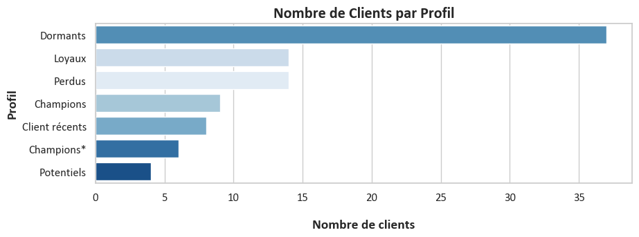

```python
# Nombre de clients par profil
plt.figure(figsize=(10,3))
plt.title("Nombre de Clients par Profil")
sns.countplot(data = rfm, y='Profil', order=rfm['Profil'].value_counts().index , hue= 'Profil', palette='Blues')
plt.xlabel("\nNombre de clients", fontweight = 'bold')
```

```python
#Compte le nombre de clients par profil et priorité depuis rfm dans l'ordre des priorités
profil_counts_df = (rfm.groupby(['Profil' , 'DegrePriorite']).size().reset_index(name='NombreClients').sort_values(by='DegrePriorite'))

#Montant dépensé par profil
profil_counts_df["MontantTotal"] = (rfm.groupby(['Profil'])['Monetary'].sum().reset_index())['Monetary']

profil_counts_df.head(10)
```

|  | Profil | DegrePriorite | NombreClients | MontantTotal |
| --- | --- | --- | --- | --- |
| 1 | Champions* | 1 | 6 | 89967.42 |
| 0 | Champions | 2 | 9 | 98892.04 |
| 4 | Loyaux | 3 | 14 | 83000.73 |
| 2 | Client récents | 4 | 8 | 20711.29 |
| 6 | Potentiels | 5 | 4 | 12366.80 |
| 5 | Perdus | 7 | 14 | 20286.64 |
| 3 | Dormants | 8 | 37 | 204470.50 |

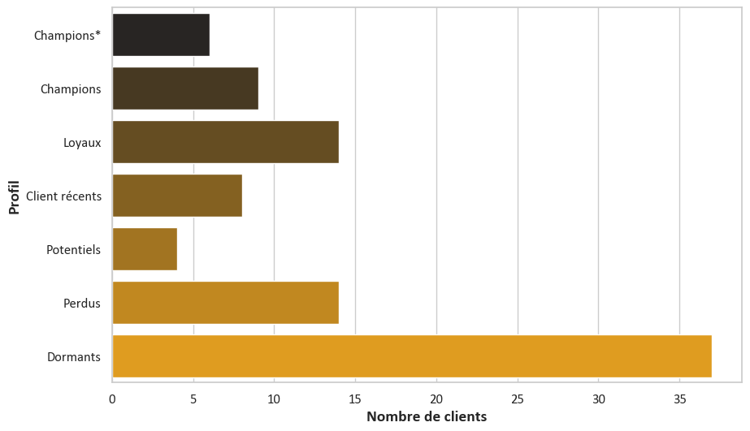

```python
# Nombre de clients par profils par ordre de priorité croissante
plt.figure(figsize=(10,6))
sns.barplot(
    data = profil_counts_df,
    y='Profil', x='NombreClients',
    order=profil_counts_df.sort_values('DegrePriorite')['Profil'],
    hue= "Profil",
    palette='dark:Orange'
)
plt.xlabel("Nombre de clients")
```

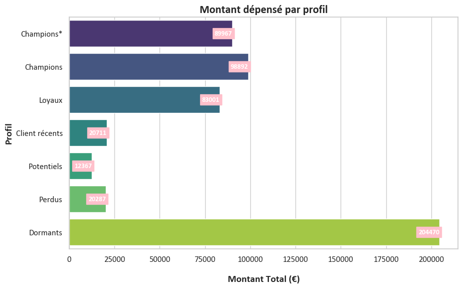

```python
plt.figure(figsize=(10,6))
ax = sns.barplot(
    data=profil_counts_df,
    y='Profil',
    x='MontantTotal',
    order=profil_counts_df.sort_values('DegrePriorite')['Profil'],
    hue='Profil',
    palette='viridis'
)
plt.title("Montant dépensé par profil")
plt.xlabel("\nMontant Total (€)")

groupe = ax.get_yticklabels()
profils = [label.get_text() for label in groupe]

for i, profil in enumerate(profils):
    j = 0
    while j <= 6 :
        if (profil_counts_df['Profil'])[j] == profil :
            plt.text((profil_counts_df['MontantTotal'])[j] , i , f'{(profil_counts_df['MontantTotal'])[j]:.0f}',
                    ha= 'right' , va = 'center' , backgroundcolor='pink' , color='white' , fontsize=10 , fontweight='bold'
                    )
        j += 1
```

```python
montant_profil_df = (rfm.groupby(['Profil' , 'DegrePriorite'])['Monetary'].sum().reset_index().sort_values(by='DegrePriorite'))

montant_profil_df.head(10)
```

|  | Profil | DegrePriorite | Monetary |
| --- | --- | --- | --- |
| 1 | Champions* | 1 | 89967.42 |
| 0 | Champions | 2 | 98892.04 |
| 4 | Loyaux | 3 | 83000.73 |
| 2 | Client récents | 4 | 20711.29 |
| 6 | Potentiels | 5 | 12366.80 |
| 5 | Perdus | 7 | 20286.64 |
| 3 | Dormants | 8 | 204470.50 |